# Markdown

Aashish Pandey

26 February 2016

This Markdown was written for Python however it will work with R as well (Only Markdown)

## insert a image in your page

[figure not shown]

# Welcome to Python Workshop

## Before moving to python part, we will see very brief capabilities of jupyter markdown

### In markdown # is used to define header, so single # will be first level header, ## will be second level header and so on. This text is written in third level header

#### You can change the cell type from above dropdown from markdown to code for writing python code

# Alternative headings with ==

Emphasis, aka italics, with *asterisks* or *underscores*.

Strong emphasis, aka bold, with **asterisks** or **underscores**.

Strikethrough uses two tildes. Scratch this.

Underline text with HTML u tag

### Lists

- unordered item 1
- unordered item 2
- unordered subitem 1
- unordered subitem 2
- unordered item 3
1. ordered item 1
2. ordered item 2
3. ordered sub item 1
4. ordered item 2
5. ordered item 3

### LaTex

- Add:
- $x + y$
- Subtract:
- $x - y$
- Multiply
- $x * y$
- $x \times y$
- $x . y$
- Divide
- $x / y$
- $x \div y$
- $\frac{x}{y}$
- Relations
  - $\pi \approx 3.14159$
  - ${1 \over 0} \neq \inf$
  - $0 < x > 1$
  - $0 \leq x \geq 1$
- Fractions
  - $^1/_2$
  - $\frac{1}{2x}$
  - ${3 \over 4}$
- Power & Index
  - $f(x) = x^2 - x^{1 \over \pi}$
  - $f(X,n) = X_n + X_{n-1}$

Let’s get summary of cars data set in R

[figure not shown]

```r
plot(cars)
```

```r
summary(cars)
```

```
##      speed           dist
##  Min.   : 4.0   Min.   :  2.00
##  1st Qu.:12.0   1st Qu.: 26.00
##  Median :15.0   Median : 36.00
##  Mean   :15.4   Mean   : 42.98
##  3rd Qu.:19.0   3rd Qu.: 56.00
##  Max.   :25.0   Max.   :120.00
```

Let’s plot now

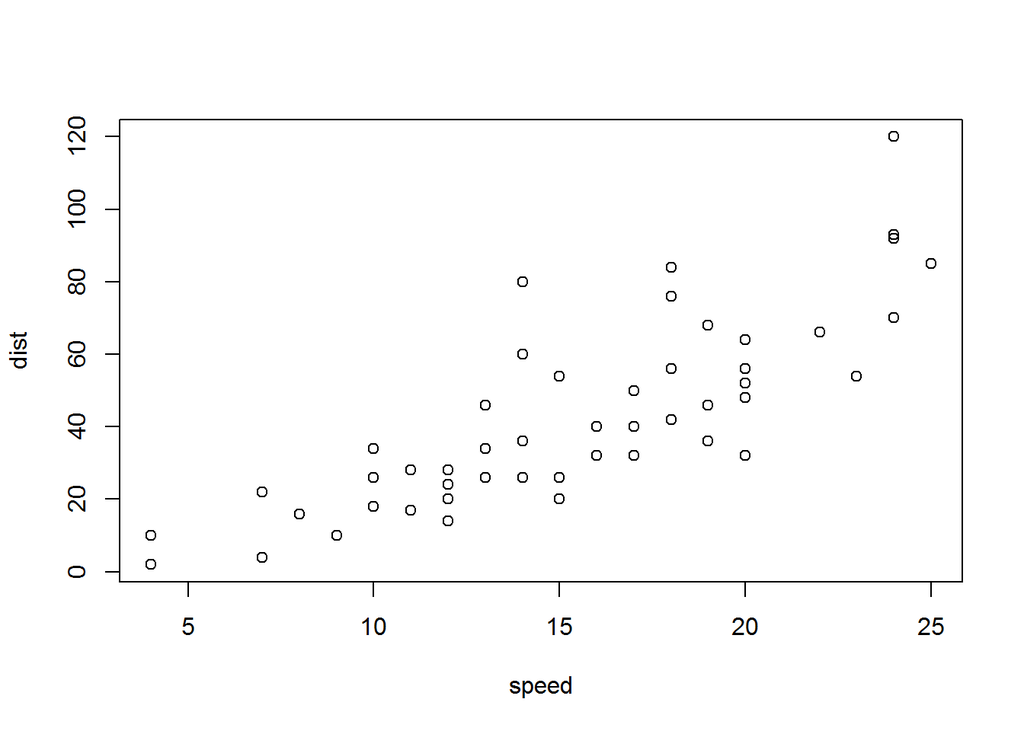

```r
plot(cars)
```